# Novokeynesiánska Phillipsova krivka pre ekonomiku Francúzska

Odhad NKPC metódami GMM, NLS a ML

Bc. P.-J. N.

Bc. V. K.

Bc. A. B.

Mgr. Dana Kozáková

(Skupina 02, Tím 07)

12. 07. 2026

# Príklad 1: Voľba ekonomiky a príprava dát

Analyzujeme ekonomiku **Francúzska (FRA)** v štvrťročnej frekvencii za obdobie **2003Q2 – 2025Q1**.

Použité datasety pochádzajú z databáz OECD a FRED (Federal Reserve Economic Data):

- **Index spotrebiteľských cien (CPI)** – FRED: `FRACPIALLQINMEI`, štvrťročne od 1955
- **Reálne HDP** – FRED: `CLVMNACSCAB1GQFR`, štvrťročne od 1980
- **Jednotkové náklady práce (ULC)** – ECB/OECD, štvrťročne od 1978 (aproximácia *labor income share*)
- **Dlhodobá úroková miera** – FRED: `IRLTLT01FRQ156N`, štvrťročne od 1980
- **Krátkodobá úroková miera** – ECB: Cost of borrowing, mesačne od 2003 (agregácia na Q)
- **Mzdy** – ECB/OECD: nominálne mzdy, štvrťročne od 1949
- **Deflátor** - FRED: `NGDPDSAIXFRQ` štvrťročne od roku 1980

## Príklad 1.1: Načítanie a zlúčenie dát

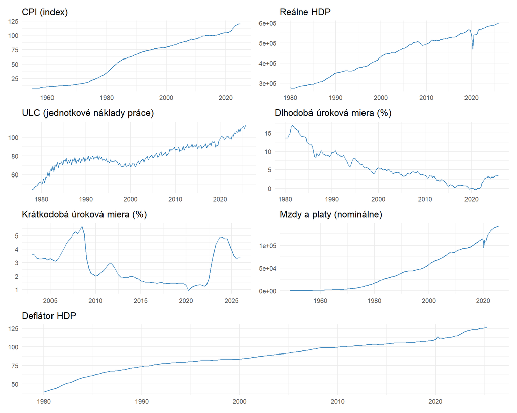

Prehľad dostupnosti surových dát

| Premenná | Začiatok | Koniec | Pozorovaní |
| --- | --- | --- | --- |
| CPI (index spotrebiteľských cien) | 1955/Q1 | 2025/Q1 | 281 |
| Reálne HDP | 1980/Q1 | 2026/Q1 | 185 |
| ULC (jednotkové náklady práce) | 1978/Q1 | 2025/Q4 | 192 |
| Dlhodobá úroková miera | 1980/Q1 | 2025/Q4 | 184 |
| Krátkodobá úroková miera | 2003/Q1 | 2026/Q1 | 93 |
| Mzdy a platy (nominálne) | 1949/Q1 | 2025/Q4 | 308 |
| Deflator | 1980/Q1 | 2025/Q2 | 182 |

Dáta pre Francúzsko pochádzajú z databáz FRED a ECB/OECD. Väčšina radov pokrýva obdobie od 1980 alebo skôr, avšak **krátkodobá úroková miera** (Cost of borrowing, ECB) je dostupná až od roku 2003 v mesačnej frekvencii – agregovali sme ju na štvrťročné priemery. Keďže úrokové rozpätie (spread) vstupuje do sady inštrumentov pri GMM odhade, analýza je obmedzená na obdobie **2003Q2 – 2025Q1** (~88 pozorovaní). HP filter aplikujeme na celý dostupný rozsah jednotlivých radov, čím minimalizujeme skreslenie na okrajoch filtrácie.

# Príklad 2: Odhad novokeynesiánskej Phillipsovej krivky (NKPC)

## Príklad 2.1: Transformácia premenných a HP filter

Na základe surových radov skonštruujeme stacionárne modelové premenné – percentuálne odchýlky od ustálených stavov pomocou HP filtra ($\lambda = 1600$ pre štvrťročné dáta).

Obdobie analýzy: **2003Q2** – **2025Q1** (88 pozorovaní).

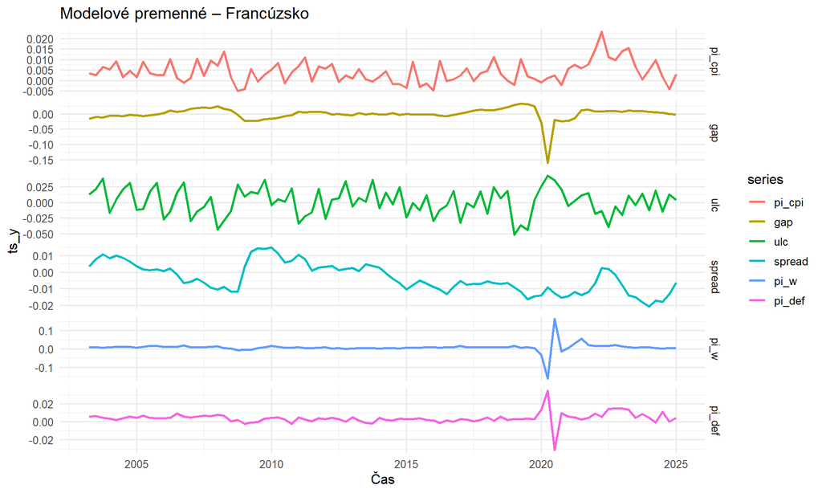

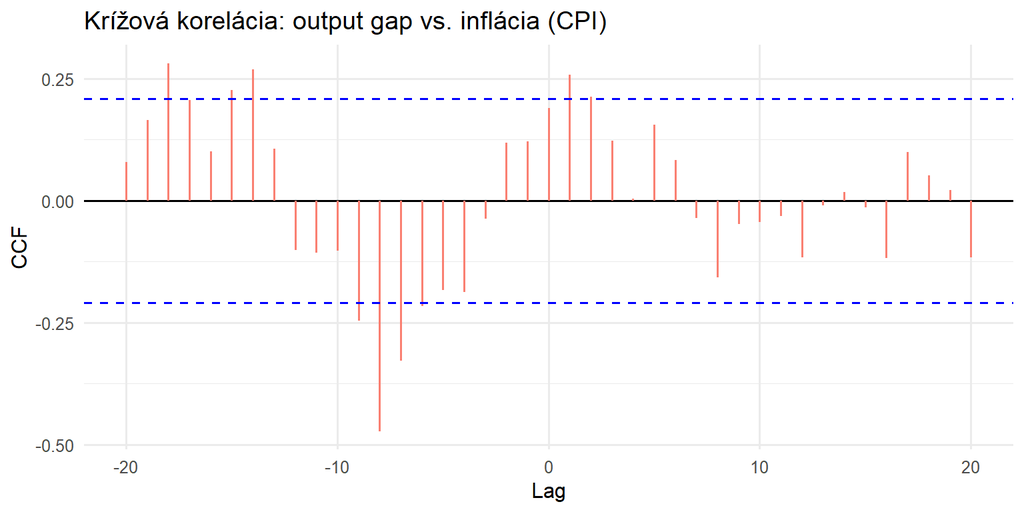

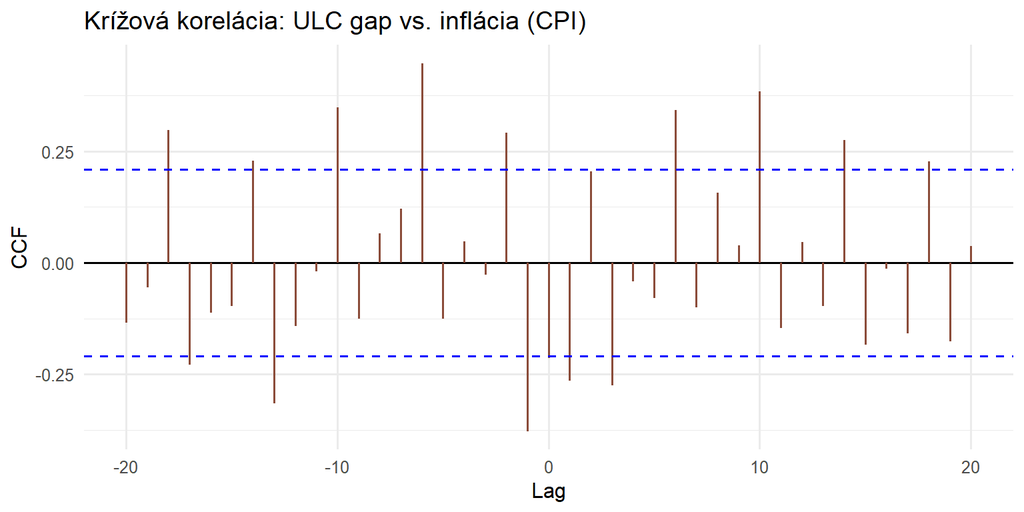

Krížové korelogramy zobrazujú vzťah medzi inflačnou dynamikou a dvoma alternatívnymi proxy premennými reálnych mezných nákladov – output gapom a odchýlkou ULC od trendu.

V prípade output gapu korelácie s infláciou vykazujú nepravidelný a nestabilný vzor – väčšina hodnôt leží vo vnútri konfidenčného pásma, avšak pri záporných lagoch okolo −7 až −10 sa objavujú výrazné záporné korelácie (až −0.50), čo je ekonomicky ťažko interpretovateľné a nie je v súlade s predpokladmi NKPC. Neexistuje systematická pozitívna korelácia, ktorá by indikovala dopredu pozerajúce správanie firiem. Output gap teda nie je spoľahlivým prediktorom inflácie vo francúzskej ekonomike za sledované obdobie.

V prípade ULC gapu je vzor korelácií výrazne odlišný. Pri kladných lagoch (ULC predchádza inflácii) sa objavujú pozitívne a štatisticky významné korelácie, čo je konzistentné s teóriou NKPC: rast jednotkových nákladov práce sa s určitým oneskorením premietne do cenovej dynamiky. Zároveň pri zápornom lagu −1 je viditeľná výrazná negatívna korelácia, čo môže odrážať cyklické pohyby spoločné pre oba rady. Celkový vzor podporuje použitie ULC ako primárnej proxy premennej reálnych mezných nákladov v následných GMM odhadoch.

## Príklad 2.2: GMM odhady NKPC

### Základná dopredu pozerajúca NKPC (redukovaná forma)

|  | Model 1a |
| --- | --- |
| Theta[1] | 0.041 |
|  | (0.057) |
| Theta[2] | 1.006*** |
|  | (0.093) |
| Num.Obs. | 85 |
| J-test | 3.281 |
| J-test p-hodnota | 0.915 |

+ p < 0.1, * p < 0.05, ** p < 0.01, *** p < 0.001

Vysoká p-hodnota J-testu (0,915) spolehlivě potvrzuje validitu a exogenitu použitých instrumentů. Parametr citlivosti na náklady (Theta 1) dosáhl hodnoty 0,041, což je v souladu s teorií, nicméně tento parametr je statisticky nevýznamný. Odhad diskontního faktoru (Theta 2) sice vlivem nedávných extrémních inflačních šoků vyšel bodově mírně nad jedna (1,006), ale vzhledem ke směrodatné odchylce (0,093) se od jedničky statisticky významně neliší.

|  | Model 1b |
| --- | --- |
| Theta[1] | -0.039 |
|  | (0.321) |
| Theta[2] | 0.806*** |
|  | (0.213) |
| Num.Obs. | 85 |
| J-test | 12.393 |
| J-test p-hodnota | 0.134 |

+ p < 0.1, * p < 0.05, ** p < 0.01, *** p < 0.001

Z modelu s fixními váhami zjišťuji, že parametr citlivosti na náklady (Theta 1) dosáhl hodnoty -0.039, což není v souladu s teorií, nicméně tento parametr je statisticky nevýznamný. Odhad diskontního faktoru (Theta 2) sice vlivem nedávných extrémních inflačních šoků vyšel v rámci teorie a je statisticky významný. P-hodnota J-testu potvrzuje validitu a exogenitu použitých instrumentů.

### Overenie s output gap

|  | Model 2 |
| --- | --- |
| Theta[1] | 0.099*** |
|  | (0.017) |
| Theta[2] | 1.012*** |
|  | (0.065) |
| Num.Obs. | 85 |
| J-test | 7.269 |
| J-test p-hodnota | 0.508 |

+ p < 0.1, * p < 0.05, ** p < 0.01, *** p < 0.001

**Porovnanie proxy premenných:**

### Štrukturálna NKPC

|  | Model 3 |
| --- | --- |
| Theta[1] | 0.735*** |
|  | (0.073) |
| Theta[2] | 1.078*** |
|  | (0.102) |
| Num.Obs. | 85 |
| J-test | 4.912 |
| J-test p-hodnota | 0.767 |

+ p < 0.1, * p < 0.05, ** p < 0.01, *** p < 0.001

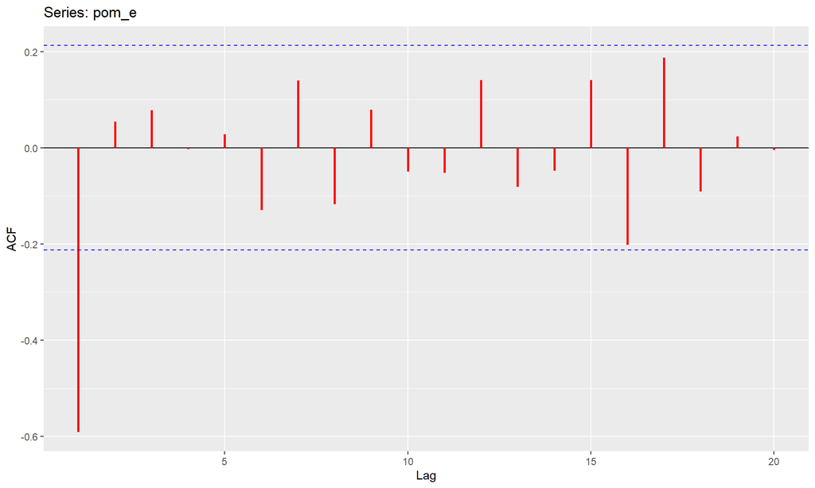

Z p-hodnoty J-testu (p = 0.77) víme, že model je validní a netrpí endogenitou. Theta 1 ($\theta$ =0,74) parametr cenové strnulosti tzv. Calvo parametr Výsledek ukazuje, že 73,5% firem v daném čtvrdletí nezmění ceny. Theta 2 ($\beta$ = 1,078) parametr je mírně nad jedna, což odporuje teorii, ale vzhledem ke směrodatné odchylce (0,102) se od jedničky statisticky neliší. Lambda parametr ($\lambda$ = 0.0746).

|  | Model 4 |
| --- | --- |
| Theta[1] | 0.788*** |
|  | (0.102) |
| Theta[2] | 1.033*** |
|  | (0.095) |
| Num.Obs. | 85 |
| J-test | 2.751 |
| J-test p-hodnota | 0.949 |

+ p < 0.1, * p < 0.05, ** p < 0.01, *** p < 0.001

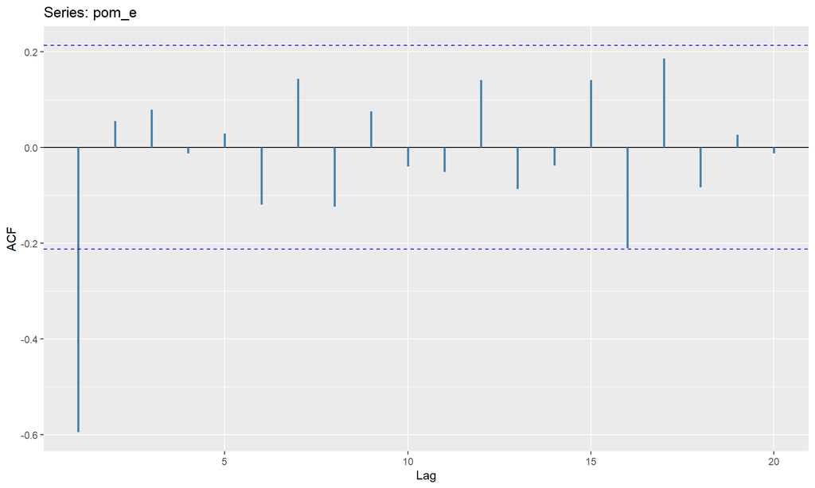

**Interpretácia štrukturálnych odhadov:**

J-test (p = 0,949) instrumenty jsou validní a striktně exogenní.Theta 1 ($\theta$ = 0,788) Calvo parametr je silně statisticky významný. Zhruba 78,8 % firem v daném čtvrtletí nemění ceny. Theta 2 ($\beta$ = 1,033) diskontní faktor je vysoce významný. Bodově leží těsně nad jedna, ale díky směrodatné odchylce (0,095) se od teoretické hodnoty 1 statisticky neliší.Lambda ($\lambda$ = 0,050) znamená plochou Phillipsovu křivku, to znamená, že centrální banka, musí výrazně intervenovat, aby snížila inflaci.

### Hybridná NKPC – redukovaná forma

$$\pi_t = \lambda mc_t + \gamma_f
E_t\{\pi_{t+1}\} + \gamma_b \pi_{t-1} + u_t$$

|  | Model 5 |
| --- | --- |
| Theta[1] | 0.235+ |
|  | (0.132) |
| Theta[2] | 0.892*** |
|  | (0.190) |
| Theta[3] | 0.146 |
|  | (0.150) |
| Num.Obs. | 85 |
| J-test | 4.874 |
| J-test p-hodnota | 0.675 |

+ p < 0.1, * p < 0.05, ** p < 0.01, *** p < 0.001

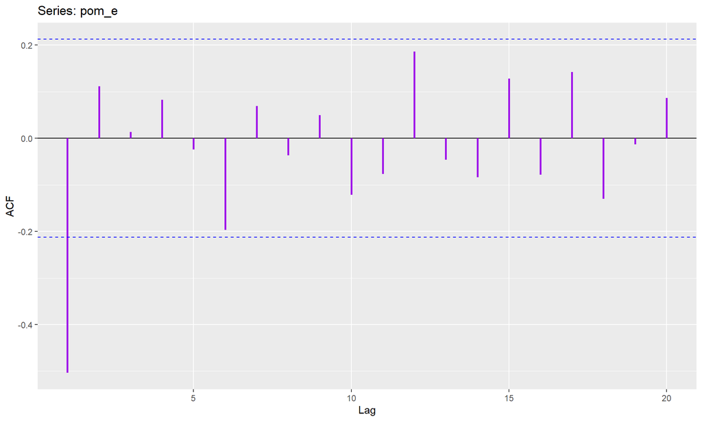

**Interpretácia hybridnej NKPC (redukovaná forma):**

J-test (p = 0,675) instrumenty jsou validní a exogenní.Theta 1 ($\lambda$ = 0,235) je citlivost na náklady. Má správné kladné znaménko a je statisticky významná na 10% hladině spolehlivosti (p = 0,075).Theta 2 ($\gamma_f$ = 0,892) je váha očekávané budoucí inflace. Hodnota tohoto parametru odpovídá teorii a je vysoce statisticky významný.Theta 3 ($\gamma_b$ = 0,145) je váha minulé inflace. Vyšla kladná, ale je statisticky nevýznamná (p = 0,332).

### Hybridná NKPC – štrukturálna forma

Odhadované parametre: **θ, β, ω** → dopočítané φ, λ, γ_f, γ_b.

|  | Model 6 |
| --- | --- |
| Theta[1] | 0.568*** |
|  | (0.136) |
| Theta[2] | 1.048*** |
|  | (0.193) |
| Theta[3] | 0.097 |
|  | (0.099) |
| Num.Obs. | 85 |
| J-test | 4.874 |
| J-test p-hodnota | 0.675 |

+ p < 0.1, * p < 0.05, ** p < 0.01, *** p < 0.001

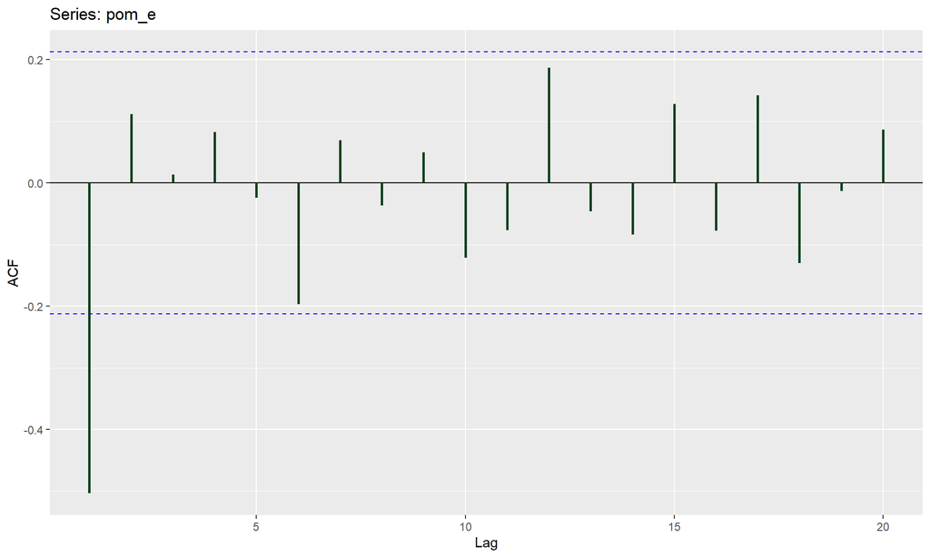

**Interpretácia hybridnej NKPC (štrukturálna forma):** J-test (p = 0,675)instrumenty jsou validní a exogenní.Theta 1 ($\theta$ = 0,568), Calvo parametr je vysoce statisticky významný. Zhruba 56,8 % firem nemění v daném čtvrtletí ceny (fixace na cca 2,3 čtvrtletí).Theta 2 ($\beta$ = 1,048) je diskontní faktor, který je vysoce významný, bodově nad jedna, ale díky odchylce (0,193) se statisticky neliší od teoretické hodnoty 1.Theta 3 ($\omega$ = 0,097) je podíl firem hledících vzad (rule-of-thumb).Tento parametr je statisticky nevýznamný (p = 0,327).